# STAT 385 Fall 2019 - Homework Assignment 03

Quinn Dellinger

Due by 12:00 PM 10/12/2019

## The Homework Problems

Below you will find problems for you to complete as an individual. It is fine to discuss the homework problems with classmates, but cheating is prohibited and will be harshly penalized if detected.

### 1. Create a custom volume measurement function that will convert the following units of volume:

1. 13 imperial (liquid) cups to cubic inches.

```r
cube<-function(cups){
result<-14.4375*cups
result
}
cube(13)
```

```
## [1] 187.6875
```

2. 2.5 US customary (liquid) gallons to fluid ounces.

```r
fl<-function(gallons){
result<-128*gallons
result
}
fl(2.5)
```

```
## [1] 320
```

3. 3 US customary (dry) teaspoons to milliliters.

```r
a_milli<-function(spoons){
result<-15*spoons
result
}
a_milli(3)
```

```
## [1] 45
```

4. 75 (dry) liters to imperial quarts.

```r
quarts<-function(liters){
result<-75*liters
result
}
quarts(75)
```

```
## [1] 5625
```

### 2. Do the following:

1. create a 25 $\times$ 25 matrix with autoregressive structure with $p = 9/10$, every element in the matrix should be equal to $(9/10)^{|i-j|}$ where `i` is the row index and `j` is the column index. Report the row and column sums of this matrix.

```r
auto <- matrix(,nrow=25,ncol=25)
for (row in 1:nrow(auto)){
for (column in 1:ncol(auto)){
auto[row,column]<-(9/10)^abs(row-column)
}}
column_sums<-apply(auto,2,sum)
row_sums<-apply(auto,1,sum)
column_sums
```

```
##  [1]  9.282102 10.102336 10.823706 11.454229 12.000910 12.469823 12.866179
##  [8] 13.194382 13.458077 13.660195 13.802983 13.888025 13.916268 13.888025
## [15] 13.802983 13.660195 13.458077 13.194382 12.866179 12.469823 12.000910
## [22] 11.454229 10.823706 10.102336  9.282102
```

```r
row_sums
```

```
##  [1]  9.282102 10.102336 10.823706 11.454229 12.000910 12.469823 12.866179
##  [8] 13.194382 13.458077 13.660195 13.802983 13.888025 13.916268 13.888025
## [15] 13.802983 13.660195 13.458077 13.194382 12.866179 12.469823 12.000910
## [22] 11.454229 10.823706 10.102336  9.282102
```

2. run the commands:

```r
set.seed(13)
x <- c(10, 10)
n <- 2
```

Create a while loop which concatenates a new mean-zero normal random variables that have $\sigma = 2$ to the existing vector `x` at every iteration. Have this loop terminate when the standard error (estimated standard deviation of `x` divided by $\sqrt{n}$) is lower than 1/10. Report $n$.

```r
set.seed(13)
x<-c(10,10)
n<-2
se<-sd(x)/sqrt(n)
while (se == 0 || se > (1/10)) {
random<-rnorm(1,mean=0,sd=2)
x<-append(x,random)
n<-n+1
se<-sd(x)/sqrt(n)
}
n
```

```
## [1] 483
```

3. repeat part **b** and report $n$ after running the commands:

```r
set.seed(13)
x <- rnorm(1,mean = 0, sd = 2)
n <- 1
```

```r
se<-2
while (se > (1/10)) {
random<-rnorm(1,mean=0,sd=2)
x<-append(x,random)
n<-n+1
se<-sd(x)/sqrt(n)
}
n
```

```
## [1] 484
```

### 3. Do the following (Efron’s bootstrap):

1. load in the dataset [dataHW3.csv](https://uofi.box.com/shared/static/mwntzgp2rvyewf292k6i62pykjz1onnw.csv)

```r
data<-read.csv("dataHW3.csv")
```

2. call the first column of this dataset x. Compute the statistic `(mean(x) - 10)/se(x)` where `se` is shorthand for standard error (see the previous problem for the definition of standard error).

```r
x<-data[,1]
stat<-(mean(x)-10)/(sd(x)/sqrt(length(x)))
stat
```

```
## [1] -0.1915867
```

3. now resample the elements of x with replacement 10000 times, and compute and store the statistic (mean(x’) - mean(x))/se(x’) at each iteration where x’ corresponds to the resample of the elements of x. Call the vector which contains these reasampled statistics `resamples`. Use an apply function for this part.

```r
mean_x<-mean(x)

prime_matrix<-matrix(,nrow = 50, ncol = 10000)
for (i in 1:ncol(prime_matrix)){
x_prime<-sample(x,length(x),replace=TRUE)
prime_matrix[,i]<-x_prime
}

run_stat<-function(v2){
stat<-(mean(v2)-mean_x)/(sd(v2)/sqrt(length(v2)))
}

resamples<-apply(prime_matrix,2,run_stat)
```

4. run the command `hist(resamples, breaks = 20)` to make a histogram, include this histogram in your assignment.

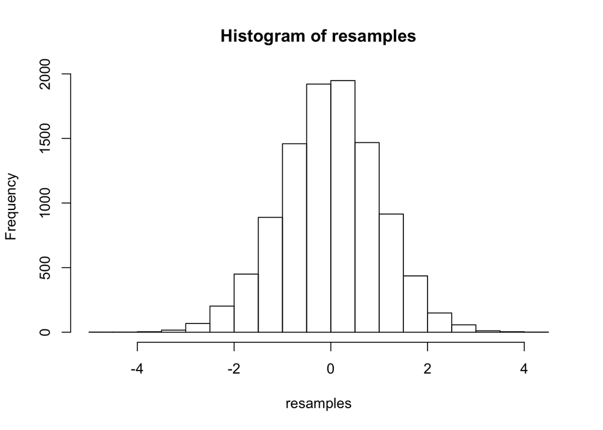

```r
hist(resamples, breaks = 20)
```

5. repeat parts **b** through **d** with respect to the second column of dataHW3.csv. Would you say that the test statistic calculated from each column has the same distribution?

```r
x<-data[,2]
stat<-(mean(x)-10)/(sd(x)/sqrt(length(x)))
stat
```

```
## [1] -0.3257341
```

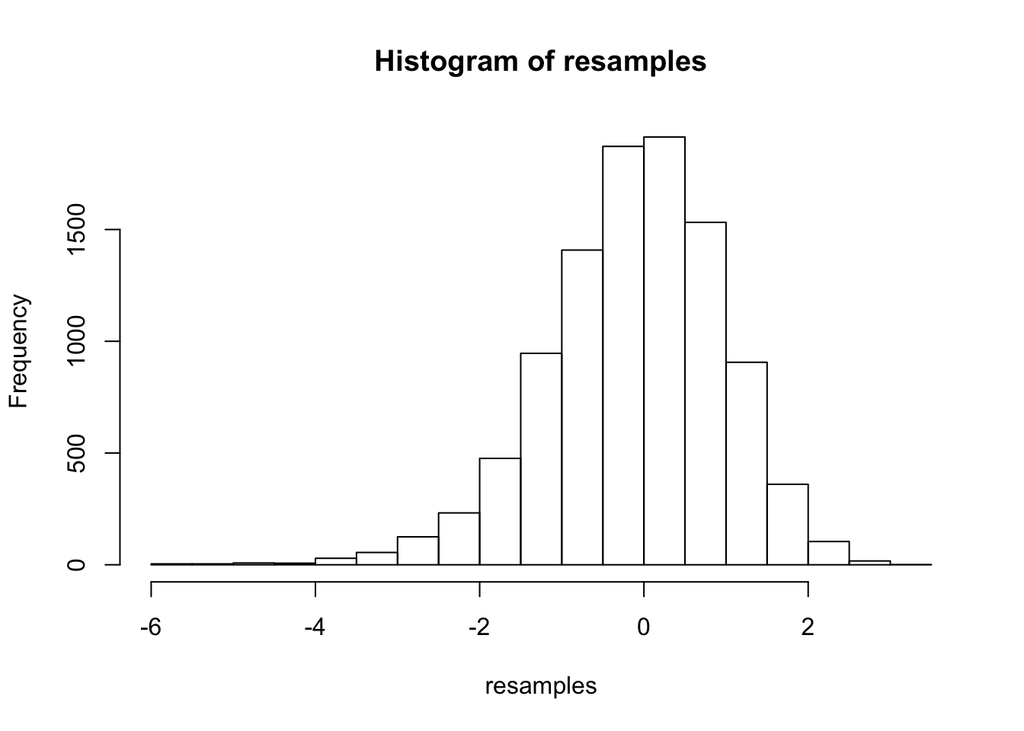

```r
mean_x<-mean(x)

prime_matrix<-matrix(data = NA, nrow = 50, ncol = 10000)
for (i in 1:ncol(prime_matrix)){
x_prime<-sample(x,length(x),replace=TRUE)
prime_matrix[,i]<-x_prime
}

resamples<-apply(prime_matrix,2,run_stat)

hist(resamples,breaks = 20)
```

### 4. Do the following:

1. make sure you have the dataset [WPP2010.csv](https://uofi.box.com/shared/static/vielwghs3qtdf2p25nejeiaq6ce9nonf.csv) (your file location may need to change) and then run the commands:

```r
# load in UN dataset and remove irrelevant variables
options(warn=-1)
WPP2010 <- read.csv("WPP2010.csv", header = TRUE)
#names third column region
colnames(WPP2010)[3] <- c("region")
#names sixth column year
colnames(WPP2010)[6] <- c("year")
#names age columns by delimiter of 5
colnames(WPP2010)[7:17] <- paste("age", 0:10 * 5, sep = "")
#restrics data down to the ages of 20-29
WPP2010 <- WPP2010[, c(3, 6, 11, 12)]

# restrict attention to countries of interest
countries <- c("Canada", "Mexico", "United States of America")

# obtain population data for all countries for all years
dataset <- WPP2010[WPP2010[, 1] %in% countries, ]
#turns age character data into numerics
dataset[, 3] <- as.numeric(levels(dataset[, 3]))[dataset[, 3]]
dataset[, 4] <- as.numeric(levels(dataset[, 4]))[dataset[, 4]]
#puts age data into thousands
dataset[, 3:4] <- dataset[, 3:4] / 1000

# get population dataset for this analysis corresponding to the
# Census years 1960, 1970, 1980, 1990, 2000, and 2010
dataset.years <- dataset[dataset[, 2] %in%
  c("1960", "1970", "1980", "1990", "2000", "2010"), ]
#factors out the years column
dataset.years[, 2] <- factor(dataset.years[, 2])
#creates list of population factored by census year
dataset.years.list <- split(dataset.years, f = as.factor(dataset.years[, 2]))
#creates population vector that holds the sums of population for NA for each census year
pops <- unlist(lapply(dataset.years.list, function(x) sum(x[, 3:4])))
#r 4c
prop <- sum(pops[1:2])/sum(pops)
paste(as.character(prop *100), "percent")
```

```
## [1] "22.6740224743095 percent"
```

2. The code in part **a** is partially commented. Add comments to all remaining lines of code to make the script clear.
3. Determine the proportion of mainland North American males aged 20-29 that lived in 1970 or before.

### 5. With the tidyverse package and its functions, do the following with the [CCSO Bookings Data](https://uofi.box.com/shared/static/9elozjsg99bgcb7gb546wlfr3r2gc9b7.csv):

install.packages(“tidyverse”) library(tidyverse)

bookings<-read_csv(“CCSO_Data.csv”) column<-bookings[,1][[1]] dates<-as.Date(column, format = “%m/%d/%Y”) bookings[,1][[1]]<-dates

1. show only the 2012 bookings for people ages 17-23 years old not residing in Illinois and show the data dimension

```r
install.packages("tidyverse", repos = "https://cloud.r-project.org/package=tidyverse")
library(tidyverse)
bookings<-read_csv("CCSO_Data.csv")
column<-bookings[,1][[1]]
dates<-as.Date(column, format = "%m/%d/%Y")
bookings[,1][[1]]<-dates
filter_1<-filter(bookings, `Age at Arrest` <= 23, `Age at Arrest` >= 17, `STATE` != "ILLINOIS", `BOOKING DATE`>="2012-01-01", `BOOKING DATE` < "2013-01-01")
View(filter_1)
dim(filter_1)
```

```
## [1] 87 35
```

2. show only the bookings for people who have employment status as “student” booked after the year 2012 residing in Danville and show the data dimension

```r
filter_2<-filter(bookings, `EMPLOYMENT STATUS` == "Student", `BOOKING DATE`>="2012-01-01", `CITY` == "DANVILLE")
head(filter_2)
```

```
## # A tibble: 6 x 35
##   `BOOKING DATE` `BOOKING NUMBER` `BOOKING TIME` `CUSTODY CLASS`
##   <date>                    <dbl> <time>         <chr>
## 1 2012-01-20         201200000355 00:16:26       Hold for other…
## 2 2012-01-20         201200000355 00:16:26       Hold for other…
## 3 2012-01-20         201200000355 00:16:26       Hold for other…
## 4 2012-02-04         201200000649 02:43:43       <NA>
## 5 2012-02-04         201200000649 02:43:43       <NA>
## 6 2012-02-04         201200000649 02:43:43       <NA>
## # … with 31 more variables: `EMPLOYMENT STATUS` <chr>, `INCARCERATION
## #   REASON` <chr>, `JACKET NUMBER` <dbl>, `JACKET TYPE` <chr>, `PRISONER
## #   TYPE` <chr>, `RELEASED DATE` <chr>, `RELEASED REASON` <chr>, `RELEASED
## #   TIME` <time>, `CHARGE/STATUTE` <chr>, `CRIME CODE` <chr>, `STATUTE
## #   TYPE` <lgl>, CITY <chr>, RACE <chr>, SEX <chr>, STATE <chr>, `ZIP
## #   CODE` <dbl>, CITIZENSHIP <chr>, `MARITIAL STATUS` <chr>,
## #   MILITARY <chr>, OCCUPATION <chr>, SCHOOL <chr>, `ARREST AGENCY` <chr>,
## #   `Age at Arrest` <dbl>, `Age at Release` <dbl>, `Booking
## #   Date/Time` <chr>, `Release Date/Time` <chr>, `Days in Jail` <dbl>,
## #   Hours <dbl>, Minutes <dbl>, Seconds <dbl>, X35 <lgl>
```

```r
dim(filter_2)
```

```
## [1] 30 35
```

3. show only the bookings for Asian people residing in the cities of Champaign or Urbana and show the data dimension

```r
filter_4<-filter(bookings, `CITY` == "CHAMPAIGN", `CITY` == "URBANA")
filter_3<-filter(bookings,`CITY` == "CHAMPAIGN", `CITY` == "URBANA", `RACE` == "Asian/Pacific Islander")
head(filter_3)
```

```
## # A tibble: 0 x 35
## # … with 35 variables: `BOOKING DATE` <date>, `BOOKING NUMBER` <dbl>,
## #   `BOOKING TIME` <time>, `CUSTODY CLASS` <chr>, `EMPLOYMENT
## #   STATUS` <chr>, `INCARCERATION REASON` <chr>, `JACKET NUMBER` <dbl>,
## #   `JACKET TYPE` <chr>, `PRISONER TYPE` <chr>, `RELEASED DATE` <chr>,
## #   `RELEASED REASON` <chr>, `RELEASED TIME` <time>,
## #   `CHARGE/STATUTE` <chr>, `CRIME CODE` <chr>, `STATUTE TYPE` <lgl>,
## #   CITY <chr>, RACE <chr>, SEX <chr>, STATE <chr>, `ZIP CODE` <dbl>,
## #   CITIZENSHIP <chr>, `MARITIAL STATUS` <chr>, MILITARY <chr>,
## #   OCCUPATION <chr>, SCHOOL <chr>, `ARREST AGENCY` <chr>, `Age at
## #   Arrest` <dbl>, `Age at Release` <dbl>, `Booking Date/Time` <chr>,
## #   `Release Date/Time` <chr>, `Days in Jail` <dbl>, Hours <dbl>,
## #   Minutes <dbl>, Seconds <dbl>, X35 <lgl>
```

```r
dim(filter_3)
```

```
## [1]  0 35
```

4. repeat parts a-c using only pipe operators

```r
select(bookings, `Age at Arrest`, `STATE`, `BOOKING DATE`) %>%
  filter(`Age at Arrest` <= 23, `Age at Arrest` >= 17, `BOOKING DATE`>= "2012-01-01", `BOOKING DATE` < "2013-01-01", `STATE` != "ILLINOIS") %>%
  dim()
```

```
## [1] 87  3
```

```r
select(bookings, `EMPLOYMENT STATUS`,`BOOKING DATE`,`CITY`) %>%
  filter(`EMPLOYMENT STATUS` == "Student", `BOOKING DATE` >= "2012-01-01", `CITY` == "DANVILLE") %>%
  dim()
```

```
## [1] 30  3
```

```r
select(bookings, `CITY`, `RACE`) %>%
  filter(`CITY` == "CHAMPAIGN", `CITY` == "URBANA", `RACE` == "Asian/Pacific Islander") %>%
  dim()
```

```
## [1] 0 2
```